# Simple 3-state microsimulation model

Includes sex specific probability of dying when healthy and state occupation: probability of dying when sick depends on the time of being sick

The DARTH workgroup

Developed by the Decision Analysis in R for Technologies in Health (DARTH) workgroup:

- Fernando Alarid-Escudero, PhD (1)
- Eva A. Enns, MS, PhD (2)
- M.G. Myriam Hunink, MD, PhD (3,4)
- Hawre J. Jalal, MD, PhD (5)
- Eline Krijkamp, PhD (6)
- Petros Pechlivanoglou, PhD (7,8)
- Alan Yang, MSc (8)

In collaboration of:

1. Stanford University, Stanford, CA, USA
2. University of Minnesota School of Public Health, Minneapolis, MN, USA
3. Erasmus MC, Rotterdam, The Netherlands
4. Harvard T.H. Chan School of Public Health, Boston, USA
5. University of Ottawa, Ottawa, ON, Canada
6. Erasmus University, Rotterdam, The Netherlands
7. University of Toronto, Toronto ON, Canada
8. The Hospital for Sick Children, Toronto ON, Canada

Please cite our publications when using this code:

- Jalal H, Pechlivanoglou P, Krijkamp E, Alarid-Escudero F, Enns E, Hunink MG. An Overview of R in Health Decision Sciences. Med Decis Making. 2017; 37(3): 735-746. https://journals.sagepub.com/doi/abs/10.1177/0272989X16686559
- Krijkamp EM, Alarid-Escudero F, Enns EA, Jalal HJ, Hunink MGM, Pechlivanoglou P. Microsimulation modeling for health decision sciences using R: A tutorial. Med Decis Making. 2018;38(3):400–22. https://journals.sagepub.com/doi/abs/10.1177/0272989X18754513
- Krijkamp EM, Alarid-Escudero F, Enns E, Pechlivanoglou P, Hunink MGM, Jalal H. A Multidimensional Array Representation of State-Transition Model Dynamics. Med Decis Mak. 2020;40(2):242-248. https://doi.org/10.1177/0272989X19893973

Change `eval` to `TRUE` if you want to knit this document.

# 01 Load packages

```r
if (!require('pacman')) install.packages('pacman'); library(pacman)
# load (install if required) packages from CRAN
p_load("devtools", "dplyr", "scales", "ellipse", "ggplot2", "lazyeval", "igraph", "truncnorm", "ggraph", "reshape2", "knitr", "markdown", "stringr", "dampack")
# load (install if required) packages from GitHub
# install_github("DARTH-git/darthtools", force = TRUE) # Uncomment if there is a newer version
p_load_gh("DARTH-git/darthtools")
```

# 02 Load functions

```r
# No functions needed
```

# 03 Model input

## 03.1 Define model input parameters

```r
## General setup
set.seed(1)                                      # set the seed
cycle_length    <- 1                             # cycle length equal to one year (use 1/12 for monthly)
n_cycles        <- 60                            # number of cycles
v_names_cycles  <- paste("cycle", 0:n_cycles)    # cycle names
v_names_states  <- c("H", "S", "D")              # state names, Healthy (H), Sick (S), Dead (D)
n_states        <- length(v_names_states)        # number of health states
n_i             <- 10000                         # number of individuals

### Discounting factors
d_c <- 0.03 # annual discount rate for costs
d_e <- 0.03 # annual discount rate for QALYs

### Strategies
v_names_str     <- c("Standard of Care",         # store the strategy names
                     "Treatment A",
                     "Treatment B")
n_str           <- length(v_names_str)           # number of strategies

### Transition probabilities
# (all non-dead probabilities are conditional on survival)
p_HS_SoC    <- 0.05  # probability of becoming sick when healthy, conditional on surviving, under standard of care
p_HS_trtA   <- 0.04  # probability of becoming sick when healthy, conditional on surviving, under treatment A
p_HS_trtB   <- 0.02  # probability of becoming sick when healthy, conditional on surviving, under treatment B
p_HD_female <- 0.0382  # probability healthy -> dead when female
p_HD_male   <- 0.0463  # probability healthy -> dead when male
df_p_HD     <- data.frame(Sex = c("Female", "Male"), p_HD = c(p_HD_female, p_HD_male)) #dataframe for sex specific mortality when healthy
p_SD        <- c(0.1, 0.2, 0.3, 0.4, 0.5, rep(0.7, n_cycles - 5)) # probability to die in sick state by cycle of being sick

### State rewards
#### Costs
c_H        <- 400   # cost of one cycle in healthy state
c_S        <- 1000  # cost of one cycle in sick state
c_D        <- 0     # cost of one cycle in dead state
c_trtA     <- 800   # cost of treatment A (per cycle) in healthy state
c_trtB     <- 1500  # cost of treatment B (per cycle) in healthy state
#### Utilities
u_H        <- 1     # utility when healthy
u_S        <- 0.5   # utility when sick
u_D        <- 0     # utility when dead
```

## 03.2 Calculate internal model parameters

```r
### Cycle-specific discount weight for costs and effects
v_dwc     <- 1 / ((1 + (d_e * cycle_length)) ^ (0:n_cycles))
v_dwe     <- 1 / ((1 + (d_c * cycle_length)) ^ (0:n_cycles))
```

# 04 Sample individual level characteristics

## 04.1 Static characteristics

```r
# randomly sample the sex of an individual (50% female)
v_sex <- sample(x = c("Female", "Male"), prob = c(0.5, 0.5), size = n_i, replace = TRUE)
```

## 04.2 Dynamic characteristics

```r
# Specify the initial health state of the individuals
# everyone begins in the healthy state (in this example)
v_M_init  <- rep("H", times = n_i)
v_Ts_init <- rep(0, n_i)  # a vector with the time of being sick at the start of the model
```

## 04.3 Create a dataframe with the individual characteristics

```r
# create a data frame with each individual's
# ID number, treatment effect modifier, age and initial time in sick state
df_X  <- data.frame(ID = 1:n_i, Sex = v_sex, n_cycles_s = v_Ts_init, M_init = v_M_init)
# NOTE: we use n_cycles_s for the number of times being sick, we start the data frame with the initial "history" of time being sick by saving v_Ts_init. However, during the simulation this value is updated and therefore called numer of times being sick.
head(df_X) # print the first rows of the dataframe
```

```
##   ID    Sex n_cycles_s M_init
## 1  1   Male          0      H
## 2  2   Male          0      H
## 3  3 Female          0      H
## 4  4 Female          0      H
## 5  5   Male          0      H
## 6  6 Female          0      H
```

# 05 Define Simulation Functions

## 05.1 Probability function

The `Probs` function updates the transition probabilities of every cycle is shown below.

```r
Probs <- function(M_t, df_X, Trt = "SoC") {
  # Arguments:
    # M_t:  health state occupied at cycle t (character variable)
    # df_X: data frame with individual characteristics data
    # Trt:  treatment
  # Returns:
    # transition probabilities for that cycle

  # Treatment specific transition probabilities
  if (Trt == "SoC") {
    p_HS <- p_HS_SoC
  } else if (Trt == "A") {
    p_HS <- p_HS_trtA
  } else if (Trt == "B") {
    p_HS <- p_HS_trtB
  }

  # create matrix of state transition probabilities
  m_p_t           <- matrix(0, nrow = n_states, ncol = n_i)
  # give the state names to the rows
  rownames(m_p_t) <-  v_names_states

  # lookup baseline probability and rate of dying based on individual characteristics
  p_HD_all <- inner_join(df_X, df_p_HD, by = c("Sex"))
  p_HD     <- p_HD_all[M_t == "H", "p_HD"]

  # update m_p_t with the appropriate probabilities
  # (all non-death probabilities are conditional on survival)
  # transition probabilities when Healthy
  m_p_t["H", M_t == "H"] <- (1 - p_HD) * (1 - p_HS)
  m_p_t["S", M_t == "H"] <- (1 - p_HD) *      p_HS
  m_p_t["D", M_t == "H"] <-      p_HD

  # transition probabilities when Sick
  m_p_t["H", M_t == "S"] <-  0
  m_p_t["S", M_t == "S"] <-  1 - p_SD[df_X$n_cycles_s]
  m_p_t["D", M_t == "S"] <-      p_SD[df_X$n_cycles_s]

  # transition probabilities when Dead
  m_p_t["H", M_t == "D"] <- 0
  m_p_t["S", M_t == "D"] <- 0
  m_p_t["D", M_t == "D"] <- 1

  return(t(m_p_t))
}
```

## 05.2 Cost function

The `Costs` function estimates the costs at every cycle.

```r
Costs <- function (M_t, Trt = "SoC") {
  # Arguments:
    # M_t: health state occupied at cycle t (character variable)
  # Returns:
    # costs accrued in this cycle
    # Trt:  treatment

  # Treatment specific transition costs
  if (Trt == "SoC") {
    c_trt <- 0
  } else if (Trt == "A") {
    c_trt <- c_trtA
  } else if (Trt == "B") {
    c_trt <- c_trtB
  }

  c_t <- c()
  c_t[M_t == "H"] <- c_H + c_trt  # costs accrued by being healthy this cycle
  c_t[M_t == "S"] <- c_S          # costs accrued by being sick this cycle
  c_t[M_t == "D"] <- c_D          # costs at dead state

  return(c_t)  # return costs accrued this cycle
}
```

## 05.3 Health outcome function

The `Effs` function to update the utilities at every cycle.

```r
Effs <- function (M_t, cl = 1) {
  # Arguments:
    # M_t: health state occupied at cycle t (character variable)
     # cl:   cycle length (default is 1)
  # Returns:
    # QALYs accrued this cycle

  q_t <- c()
  q_t[M_t == "H"] <- u_H  # utility for being healthy this cycle
  q_t[M_t == "S"] <- u_S  # utility for being sick this cycle
  q_t[M_t == "D"] <- u_D  # utility for dead state

  QALYs <- q_t * cl  # calculate the QALYs during cycle t
  return(QALYs)      # return the QALYs accrued this cycle
}
```

## 05.4 Microsimulation function

Below we develop the microsimulation function that allows the model to be run.

```r
MicroSim <- function(n_i, df_X, seed = 1, Trt = "SoC") {
  # Arguments:
    # n_i: number of individuals
    # df_X: data frame with individual data
    # seed: seed for the random number generator, default is 1
    # Trt: treatment
  # Returns:
    # results: data frame with total cost and QALYs

  set.seed(seed) # set a seed to be able to reproduce the same results

  # create three matrices called m_M, m_C and m_E
  # number of rows is equal to the n_i, the number of columns is equal to n_cycles
  # (the initial state and all the n_cycles cycles)
  # m_M is used to store the health state information over time for every individual
  # m_C is used to store the costs information over time for every individual
  # m_E is used to store the effects information over time for every individual

  m_M <- m_C <- m_E <-  matrix(nrow = n_i, ncol = n_cycles + 1,
                               dimnames = list(paste("ind"  , 1:n_i, sep = " "),
                                               paste("cycle", 0:n_cycles, sep = " ")))

  m_M[, 1] <- as.character(df_X$M_init) # initial health state
  m_C[, 1] <- Costs(m_M[, 1])  # costs accrued during cycle 0
  m_E[, 1] <- Effs(m_M[, 1], cl = 1)   # QALYs accrued during cycle 0

  # open a loop for time running cycles 1 to n_cycles
  for (t in 1:n_cycles) {
    # calculate the transition probabilities for the cycle based on health state t
    m_P <- Probs(m_M[, t], df_X, Trt = Trt)
    # check if transition probabilities are between 0 and 1
    check_transition_probability(m_P, verbose = TRUE)
    # check if each of the rows of the transition probabilities matrix sum to one
    check_sum_of_transition_array(m_P, n_rows = n_i, n_cycles = n_cycles, verbose = TRUE)

    # sample the next health state and store that state in matrix m_M
    m_M[, t + 1]  <- samplev(m_P, 1)
    # calculate costs per individual during cycle t + 1
    m_C[, t + 1]  <- Costs(m_M[, t + 1], Trt = Trt)
    # calculate QALYs per individual during cycle t + 1
    m_E[, t + 1]  <- Effs (m_M[, t + 1], cl = 1)

    # update time since illness onset for t + 1
    # NOTE: this code has a "reset of history" for time being sick
    # once someone is not "Sick" anymore, we reset n_cycles_s (set back to zero)
    # when you don't want a "reset" replace the last zero with teh current value
    df_X$n_cycles_s <- if_else(m_M[, t + 1] == "S", df_X$n_cycles_s + 1, 0)

    # Display simulation progress
    if(t/(n_cycles/10) == round(t/(n_cycles/10), 0)) { # display progress every 10%
      cat('\r', paste(t/n_cycles * 100, "% done", sep = " "))
    }

  } # close the loop for the time points

  # calculate
  tc      <- m_C %*% v_dwc  # total (discounted) cost per individual
  te      <- m_E %*% v_dwe  # total (discounted) QALYs per individual
  tc_hat  <- mean(tc)       # average (discounted) cost
  te_hat  <- mean(te)       # average (discounted) QALY
  # store the results from the simulation in a list
  results <- list(m_M = m_M, m_C = m_C, m_E = m_E, tc = tc , te = te,
                  tc_hat = tc_hat, te_hat = te_hat)

  return(results)  # return the results

} # end of the `MicroSim` function
```

## 06 Run Microsimulation

```r
# 06 Run Microsimulation
# By specifying all the arguments in the `MicroSim()` the simulation can be started
# Run the simulation model
outcomes_SoC  <- MicroSim(n_i = n_i, df_X = df_X, seed = 1, Trt = "SoC")
```

[output not shown]

[output cut: 116 more lines]

```r
outcomes_trtA <- MicroSim(n_i = n_i, df_X = df_X, seed = 1, Trt = "A")
```

[output not shown]

[output cut: 116 more lines]

```r
outcomes_trtB <- MicroSim(n_i = n_i, df_X = df_X, seed = 1, Trt = "B")
```

[output not shown]

[output cut: 116 more lines]

# 07 Visualize results

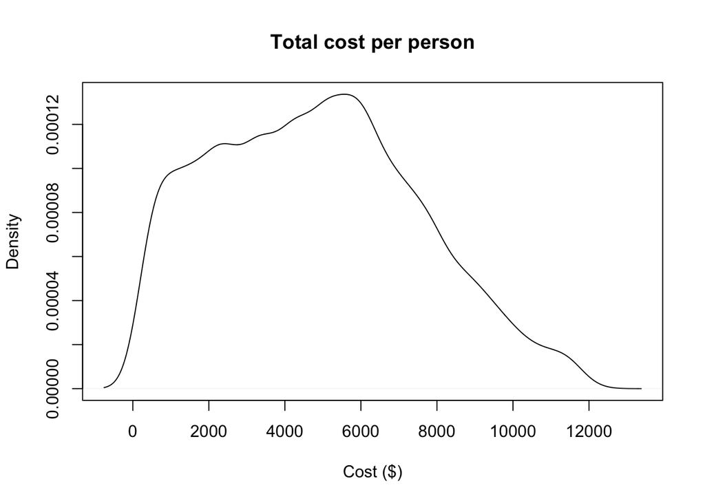

```r
# Standard of Care
plot(density(outcomes_SoC$tc), main = paste("Total cost per person"),  xlab = "Cost ($)")
```

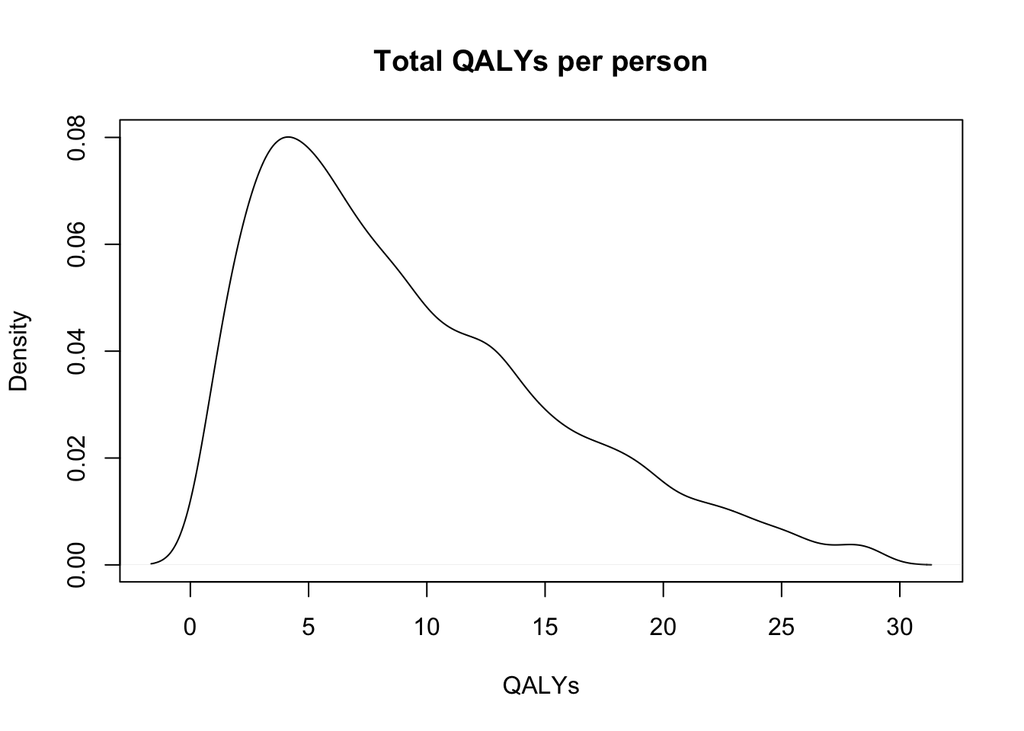

```r
plot(density(outcomes_SoC$te), main = paste("Total QALYs per person"), xlab = "QALYs")
```

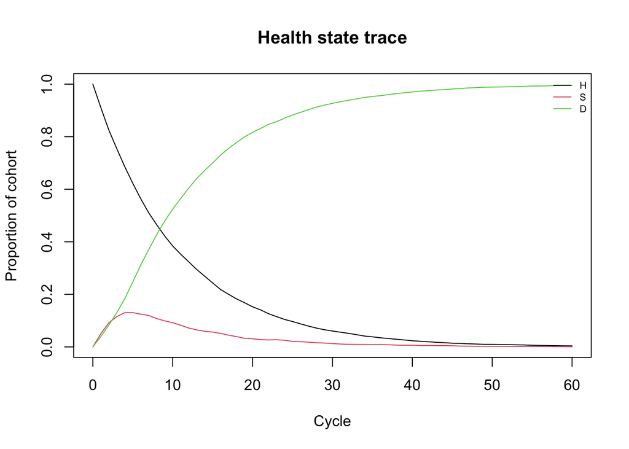

```r
plot_trace_microsim(outcomes_SoC$m_M)      # health state trace
```

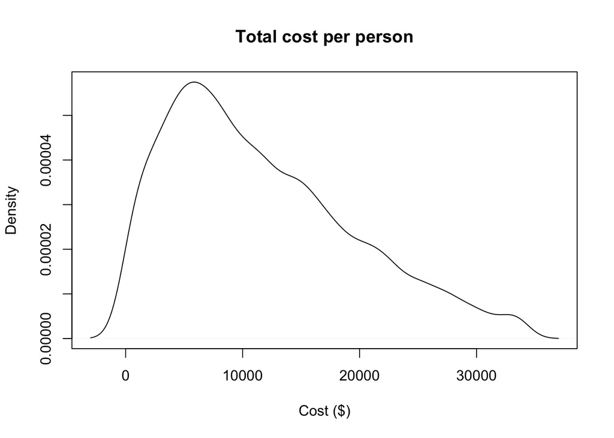

```r
# Treatment A
plot(density(outcomes_trtA$tc), main = paste("Total cost per person"),  xlab = "Cost ($)")
```

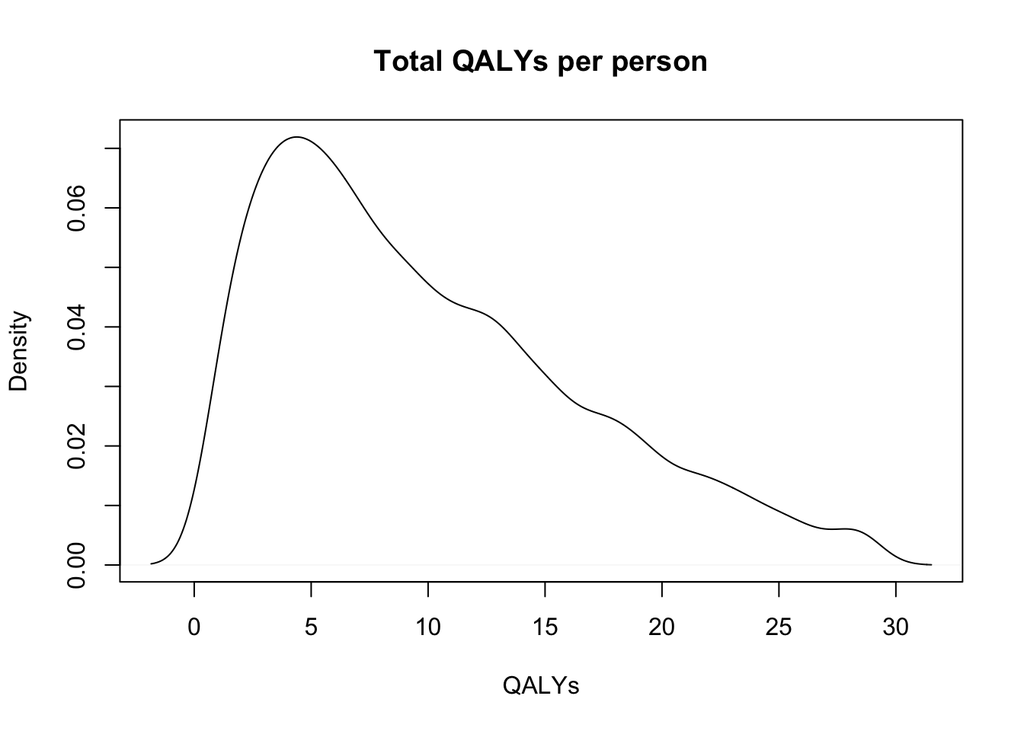

```r
plot(density(outcomes_trtA$te), main = paste("Total QALYs per person"), xlab = "QALYs")
```

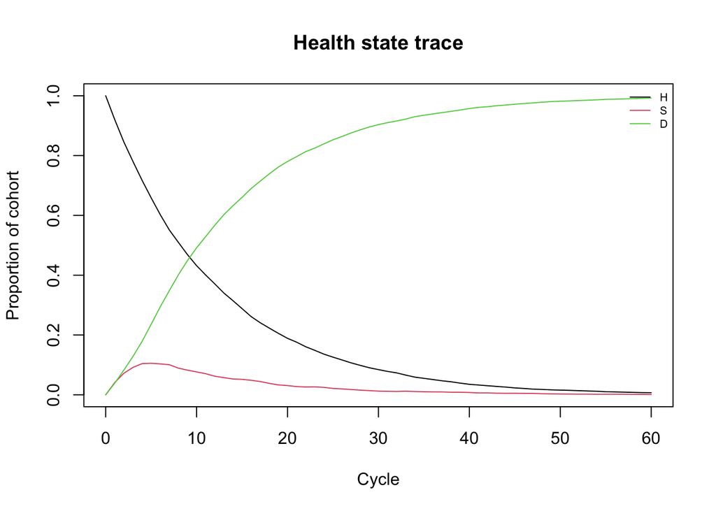

```r
plot_trace_microsim(outcomes_trtA$m_M)     # health state trace
```

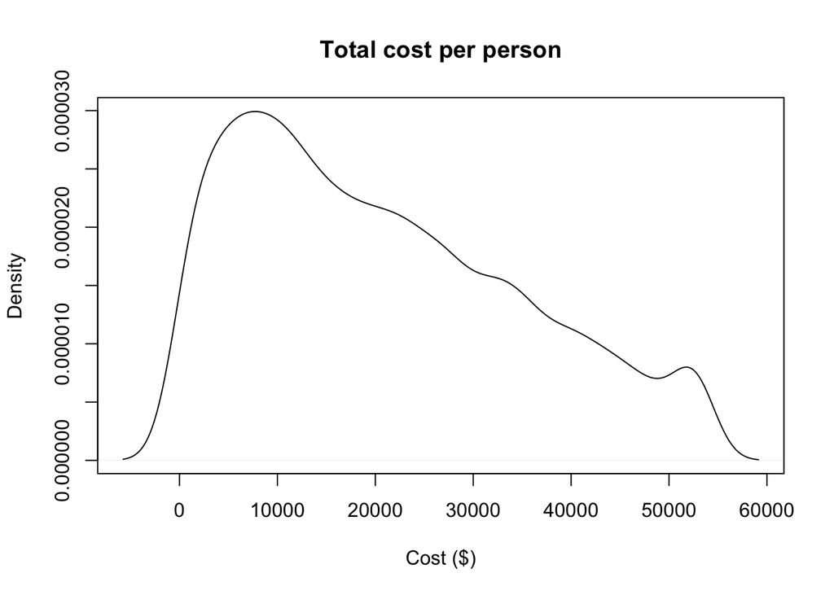

```r
# Treatment B
plot(density(outcomes_trtB$tc), main = paste("Total cost per person"),  xlab = "Cost ($)")
```

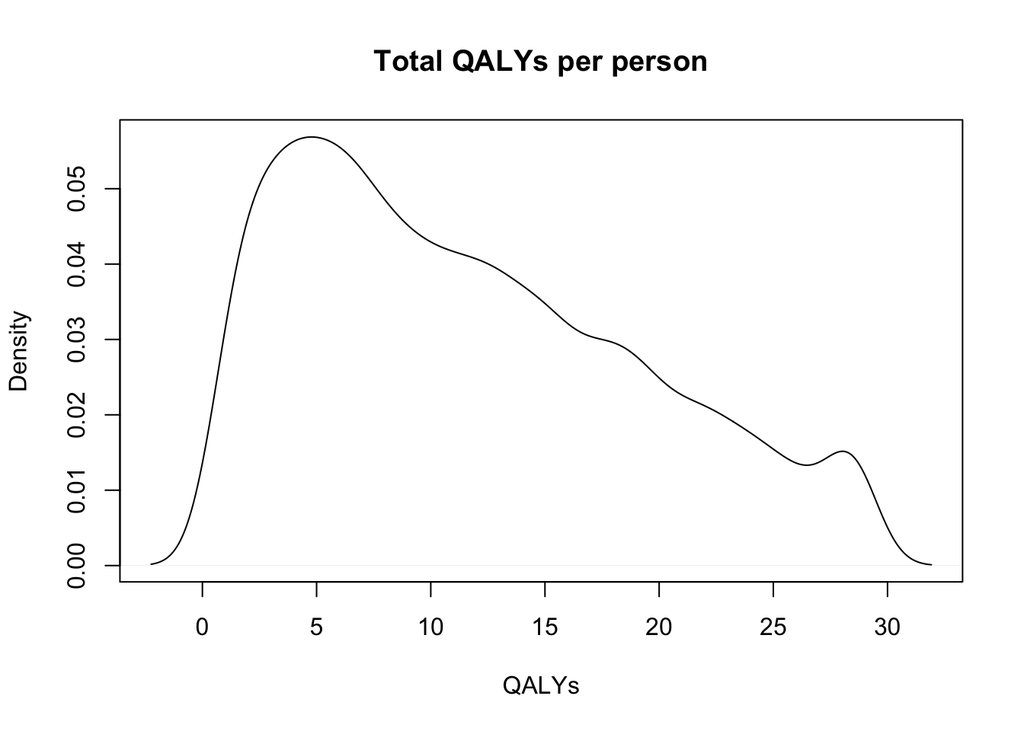

```r
plot(density(outcomes_trtB$te), main = paste("Total QALYs per person"), xlab = "QALYs")
```

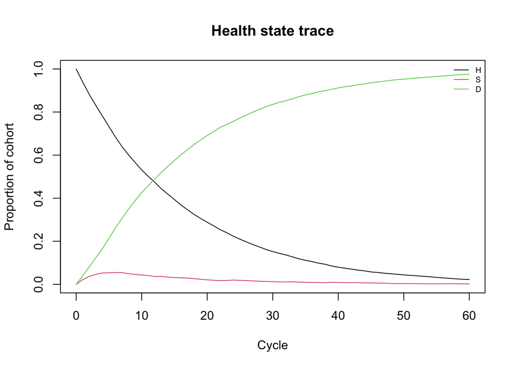

```r
plot_trace_microsim(outcomes_trtB$m_M)     # health state trace
```

# 08 Cost-effectiveness analysis (CEA)

```r
# store the mean costs of each strategy in a new variable C (vector of costs)
v_C <- c(outcomes_SoC$tc_hat, outcomes_trtA$tc_hat, outcomes_trtB$tc_hat)
# store the mean QALYs of each strategy in a new variable E (vector of effects)
v_E <- c(outcomes_SoC$te_hat, outcomes_trtA$te_hat, outcomes_trtB$te_hat)

# use dampack to calculate the ICER
df_cea <- calculate_icers(cost       = v_C,
                          effect     = v_E,
                          strategies = v_names_str)
df_cea
```

```
##           Strategy      Cost    Effect Inc_Cost Inc_Effect     ICER Status
## 1 Standard of Care  4817.465  9.262123       NA         NA       NA     ND
## 2      Treatment B 20709.997 11.670548 15892.53   2.408425 6598.724     ND
## 3      Treatment A 11630.222  9.957949       NA         NA       NA     ED
```

```r
## CEA table in proper format
table_cea <- format_table_cea(df_cea)
table_cea
```

```
##           Strategy Costs ($) QALYs Incremental Costs ($) Incremental QALYs
## 1 Standard of Care     4,817  9.26                  <NA>                NA
## 2      Treatment B    20,710 11.67                15,893              2.41
## 3      Treatment A    11,630  9.96                  <NA>                NA
##   ICER ($/QALY) Status
## 1          <NA>     ND
## 2         6,599     ND
## 3          <NA>     ED
```

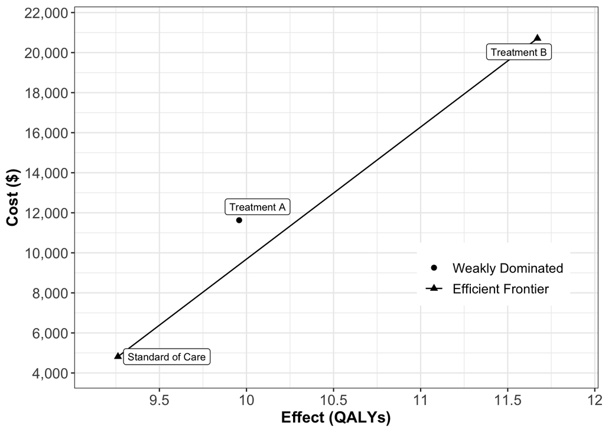

```r
## CEA frontier
plot(df_cea, label = "all", txtsize = 14) +
  expand_limits(x = max(table_cea$QALYs) + 0.1) +
  theme(legend.position = c(0.8, 0.3))
```